# Take-home Exercise 1

The objective of this take-home exercise is to practice producing robust documentation for reproducible data.

M.L. Kwong https://scis.smu.edu.sg/master-it-business (MITB (Analytics))https://scis.smu.edu.sg/  
2022-01-28

# 1.0 Overview

In this take-home exercise, we aim to apply the appropriate packages to create suitable data visualisations using ggplot2. The two main visualisations we will be covering include:

- A **pareto chart** showing the distribution of returns by product sub-category using the *superstore-2021.xls* file.
- A **age-sex pyramid** showing the demographic structure of Singapore by age cohort and gender, using the *Singapore Residents by Planning Area / Subzone, Age Group, Sex and Type of Dwelling, June 2021* from [Department of Statistics](https://www.singstat.gov.sg/).

Steps taken towards data preparation, choice of packages and findings will be documented, and outlined in separate sections for each visualisation.

# 2.0 Pareto Chart

## 2.1 Data Import

The *superstore-2021* dataset is used in this example, which comprise three worksheets: Orders, People and Returns.

Referencing the initial guide, the code chunk below was used to import the necessary packages to create the visualisation.

```r
packages = c('tidyverse', 'readxl', 'knitr')

for(p in packages){
  if(!require(p, character.only = T)){
    install.packages(p)
  }
  library(p, character.only = T)
}
```

```r
orders <- read_xls("data/Superstore-2021.xls",
                  sheet = "Orders")
returns <- read_xls("data/Superstore-2021.xls",
                  sheet = "Returns")
```

## 2.2 Data Wrangling

Steps were taken using the [guide](https://r4dsa.netlify.app/posts/2022-01-23-creating-a-pareto-chart-using-ggplot/) to:

- join the two data frames through a left join
- computer the frequency count by sub-category
- sort the data by descending returns
- computing the cumulative frequency

### Joining the two data frames

```r
joined_tab <- left_join(returns, orders,
                        by = c('Order ID' = 'Order ID'))
```

### Getting the frequency count through count method

```r
freq_returned <- joined_tab %>%
  count(`Sub-Category`) %>%
  rename(Returns = n)
```

### Computing the cumulative frequency

```r
freq_sorted <- freq_returned %>%
  arrange(desc(Returns)) %>%
  mutate(
    cumulative = cumsum(Returns) / sum(Returns)*100
  )

names(freq_sorted)[names(freq_sorted) == 'Sub-Category'] <- 'SubCategory'
freq_sorted$SubCategory <- factor(freq_sorted$SubCategory, levels=freq_sorted$SubCategory)
```

### Visualisation

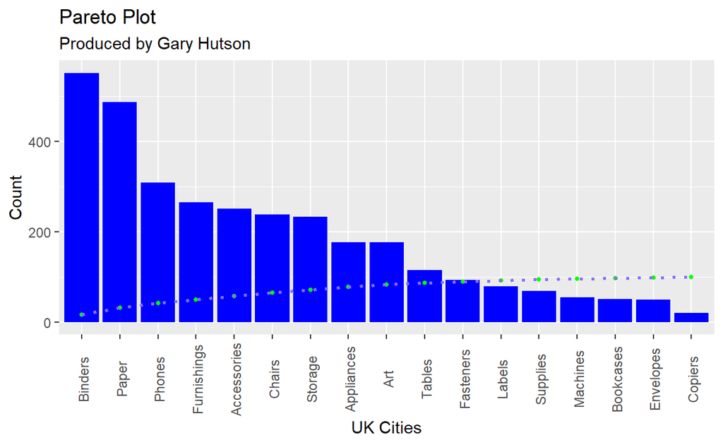

```r
ggplot(freq_sorted, aes(x=freq_sorted$SubCategory)) +
  geom_bar(aes(y=freq_sorted$Returns), fill='blue', stat="identity") +
  geom_point(aes(y=freq_sorted$cumulative), color = rgb(0, 1, 0), pch=16, size=1) +
  geom_path(aes(y=freq_sorted$cumulative, group=1), colour="slateblue1", lty=3, size=0.9) +
  theme(axis.text.x = element_text(angle=90, vjust=0.6)) +
  labs(title = "Pareto Plot", subtitle = "Produced by Gary Hutson", x = 'UK Cities', y = 'Count')
```

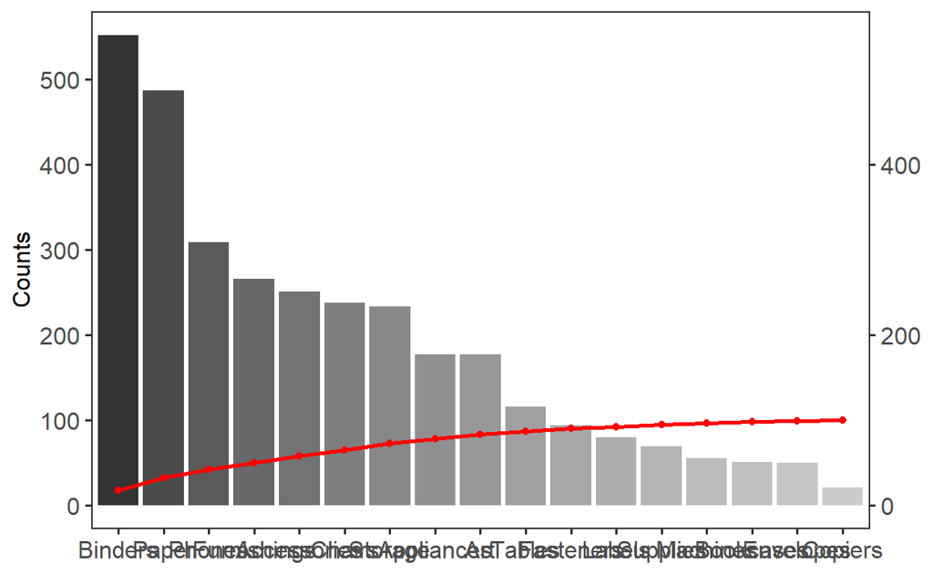

```r
ggplot(freq_sorted, aes(x=SubCategory)) +  theme_bw(base_size = 12)+
  geom_bar(aes(y=Returns, fill=SubCategory), stat="identity",show.legend = FALSE) +
  geom_path(aes(y=cumulative, group=1),colour="red", size=0.9) +
  geom_point(aes(y=cumulative, group=1),colour="red") +
  scale_y_continuous("Counts", sec.axis = sec_axis(~.), n.breaks = 9) +
  scale_fill_grey() +
  theme(
    axis.text = element_text(size=12),
    panel.grid.major = element_blank(),
    panel.grid.minor = element_blank(),
    axis.title.x=element_blank()
  )
```